# plkacy_PeerCommentary_sherryx_03

Sherry Xie

2025-03-03

*MAYBE HAVE A SET UP SECTION AT THE BEGINNING TO LOAD ALL YOUR PACKAGES?*

```r
#download the new package ggpubr first
#install.packages("ggpubr") for Q-Q plots

#loading ggplot for the figures
library(ggplot2)
library(dplyr)
library(ggpubr)
```

## Open file from downloads:

*Please change this later back to your original code. I had to change it otherwise I could not access it. Thank you!*

```r
#zombies <- read.csv("/Users/kacylin/Desktop/zombies.csv")
zombies <- read.csv("/Users/sherryxie/CODE/Github/repos/Homework/Sherry's Homework 03/zombies.csv")
```

*REMEBER TO CHANGE ALL QUESTION TO HEADER 2 FORMAT*

## 1.) Calculate the population mean and standard deviation for each quantitative random variable (height, weight, age, number of zombies killed, and years of education). NOTE: You will not want to use the built in var() and sd() commands as these are for samples.

GREAT JOB! I THINK IT IS REALLY CLEAN YOU DECIDE TO SPLIT UP THE FUNCTIONS FOR SD AND MEAN. I GROUPED THEM TOGETHER AND IT WAS A MESS. THIS IS DEFINITELY SOMETHING I WILL GO BACK AND CHANGE. THANK YOU!

```r
colnames(zombies)  # See the actual column names
```

```
##  [1] "id"                 "first_name"         "last_name"
##  [4] "gender"             "height"             "weight"
##  [7] "zombies_killed"     "years_of_education" "major"
## [10] "age"
```

```r
numeric_vars <- c("height", "weight", "age", "zombies_killed", "years_of_education")
# Calculate population mean
pop_mean <- colMeans(zombies[, numeric_vars], na.rm = TRUE)

# Calculate population standard deviation
pop_sd <- sapply(zombies[, numeric_vars], function(x) sqrt(mean((x - mean(x, na.rm = TRUE))^2, na.rm = TRUE)))

# Print results
pop_mean
```

```
##             height             weight                age     zombies_killed
##           67.63010          143.90748           20.04696            2.99200
## years_of_education
##            2.99600
```

```r
pop_sd
```

```
##             height             weight                age     zombies_killed
##           4.307970          18.391857           2.963583           1.747551
## years_of_education
##           1.675704
```

## 2.)Use {ggplot} to make boxplots of each of these variables by gender.

*^^CHANGED TO HEADER 2 SO IT LOOKS MORE ORGANIZED IN THE TABLE OF CONTENT*

Numeric variables are height, weight, age, zombies killed, and years of education

*I LIKE HOW YOU WROTE OUT EACH PART OF THE GGPLOT FUNCTION. I GROUPED MINE TOGETHER LIKE THIS*

ggplot(zombie, aes(x = gender, y = height)) + geom_boxplot() + theme_minimal()

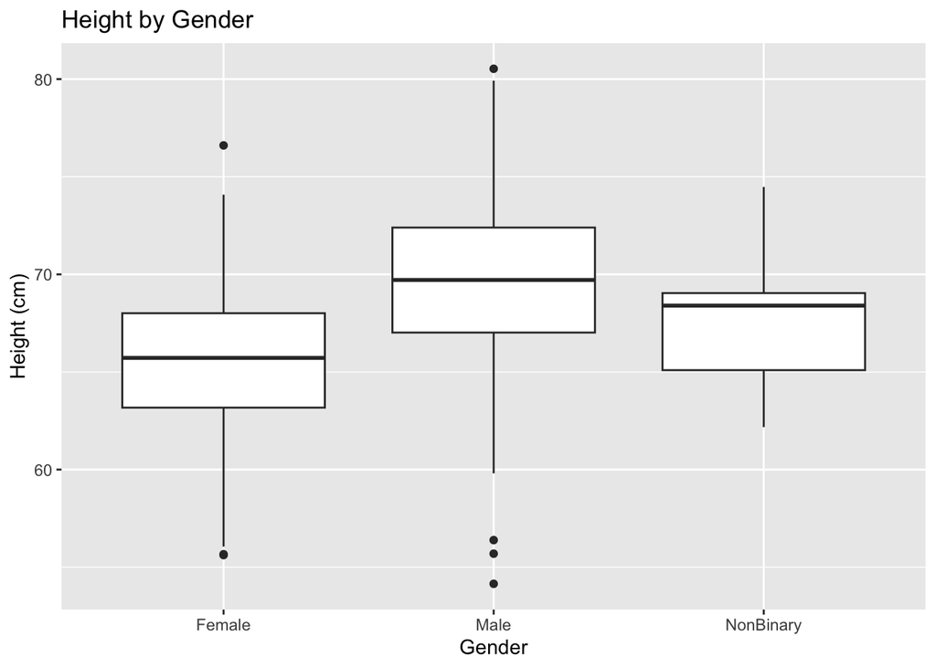

```r
#plot for gender and height
library(ggplot2)
p <- ggplot(data = zombies, aes(x = gender, y = height))  #Define variables
p <- p + geom_boxplot()  #Graph them in boxplot
p <- p + xlab("Gender") + ylab("Height (cm)")  # Rename axes
p <- p + ggtitle("Height by Gender")  # Add title
p  # Show plot
```

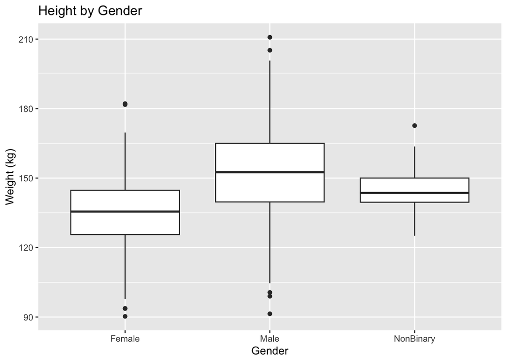

```r
#plot for weight by gender
p <- ggplot(data=zombies, aes (x=gender, y=weight))
p <- p + geom_boxplot()  #Graph them in boxplot
p <- p + xlab("Gender") + ylab("Weight (kg)")  # Rename axes
p <- p + ggtitle("Height by Gender")  # Add title
p  # Show plot
```

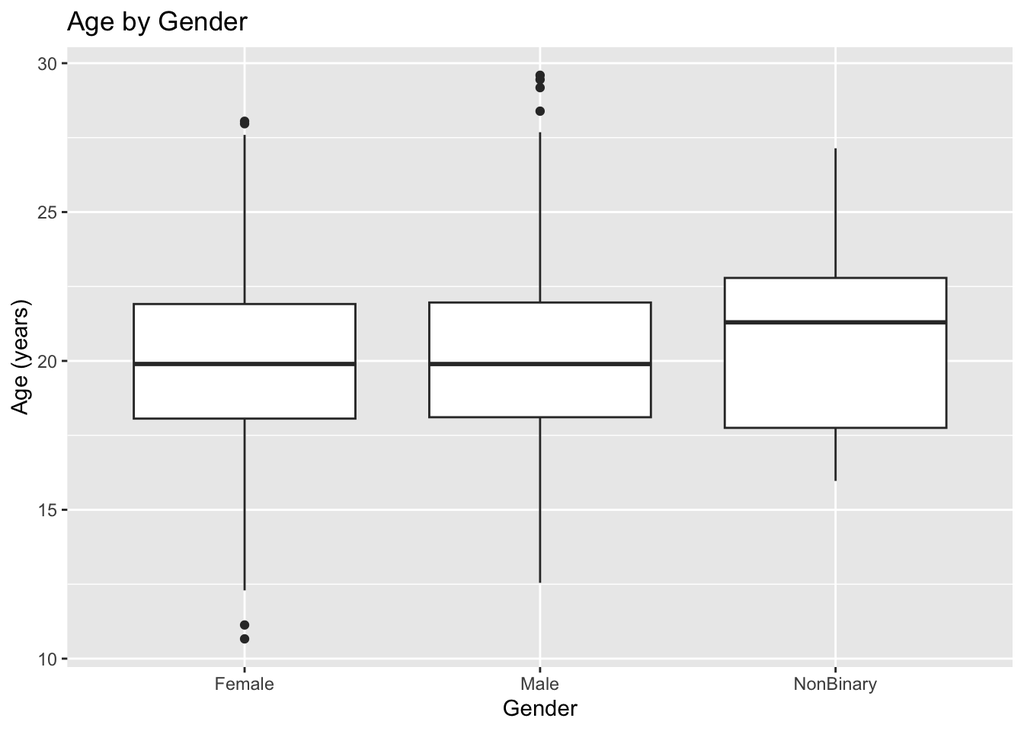

```r
#plot for gender and age
p <- ggplot(data = zombies, aes(x = gender, y = age))  #Define variables
p <- p + geom_boxplot()  #Graph them in boxplot
p <- p + xlab("Gender") + ylab("Age (years)")  # Rename axes
p <- p + ggtitle("Age by Gender")  # Add title
p  # Show plot
```

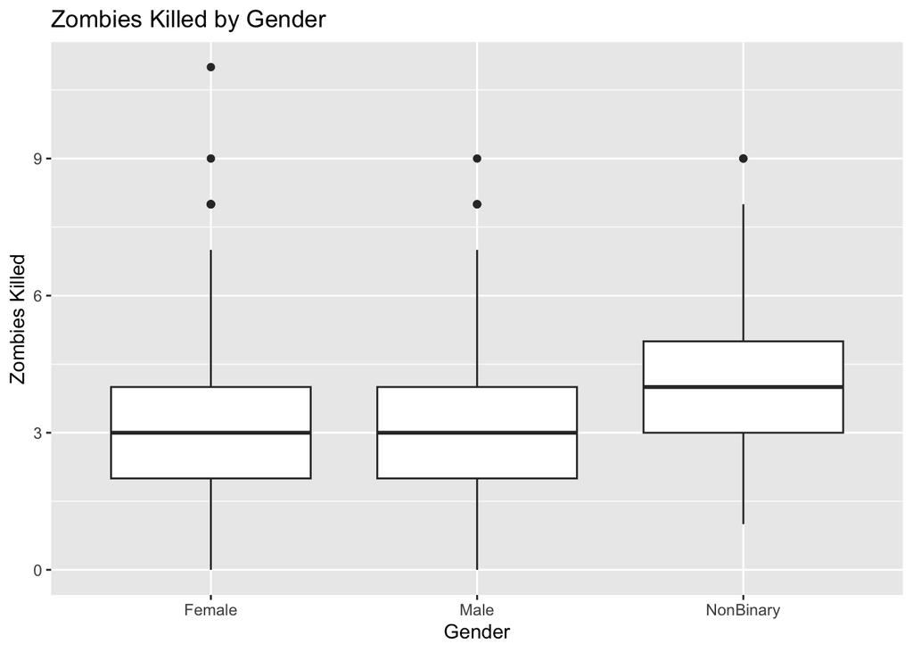

```r
#plot for gender and zombies killed
p <- ggplot(data = zombies, aes(x = gender, y = zombies_killed))
p <- p + geom_boxplot()
p <- p + xlab("Gender") + ylab("Zombies Killed")
p <- p + ggtitle("Zombies Killed by Gender")
p
```

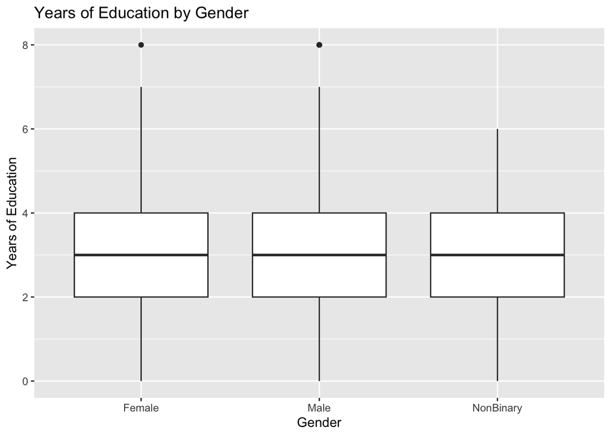

```r
#plotfor gender and years of education
p <- ggplot(data = zombies, aes(x = gender, y = years_of_education))
p <- p + geom_boxplot()
p <- p + xlab("Gender") + ylab("Years of Education")
p <- p + ggtitle("Years of Education by Gender")
p
```

## 3.) Use {ggplot} to make scatterplots of height and weight in relation to age. Do these variables seem to be related? In what way?

*^^CHANGED TO HEADER 2 SO IT LOOKS MORE ORGANIZED IN THE TABLE OF CONTENT*

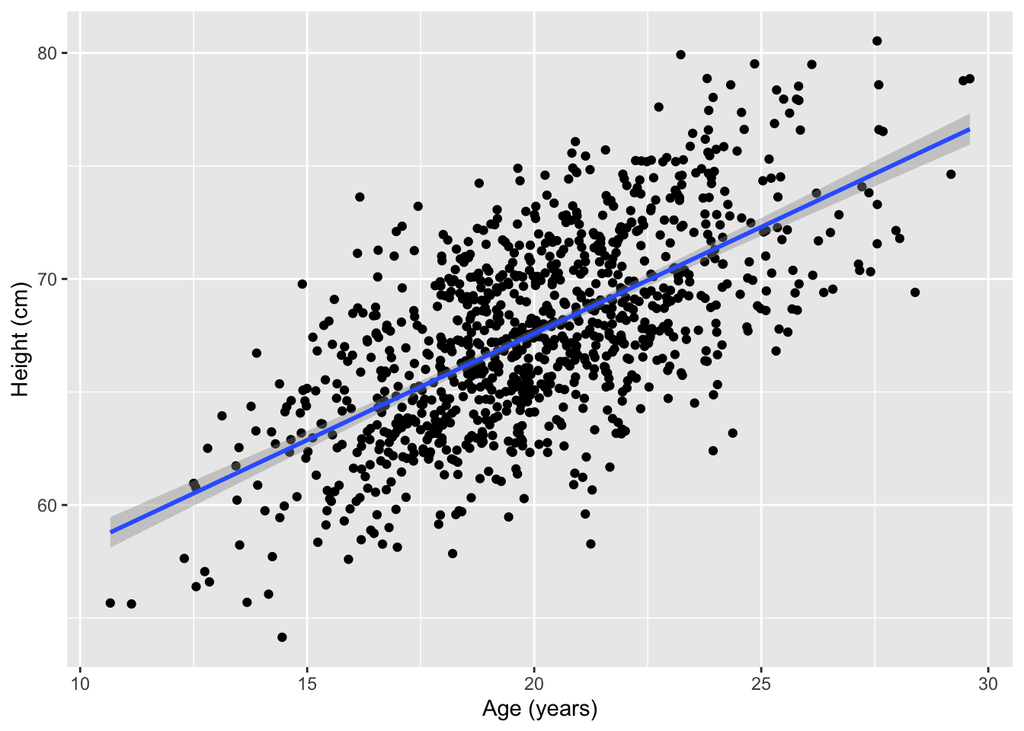

```r
#Scatterplot of height in relation to age
library(ggplot2)

p <- ggplot(data = zombies, aes(x = age, y = height))  # Define variables
p <- p + xlab("Age (years)") + ylab("Height (cm)")  # Modify axis labels
p <- p + geom_point()  # Make a scatterplot
p <- p + geom_smooth(method = "lm")  # Add a trend line
p  # Plot the object
```

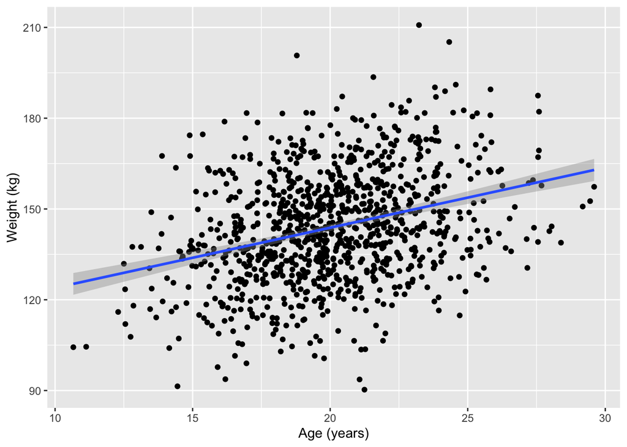

```r
#Scatterplot of weight in relation to age
p <- ggplot(data = zombies, aes(x = age, y = weight))
p <- p + xlab("Age (years)") + ylab("Weight (kg)")
p <- p + geom_point()
p <- p + geom_smooth(method = "lm")
p
```

The trendlines show a positive slope, suggesting that height/weight increases with age

*^^ I ALSO SAID THIS!! AWESOME JOB!!*

## 4.) Using histograms and Q-Q plots, check whether the quantitative variables seem to be drawn from a normal distribution. Which seem to be and which do not (hint: not all are drawn from the normal distribution)? For those that are not normal, can you determine from which common distribution they are drawn?

*^^CHANGED TO HEADER 2 SO IT LOOKS MORE ORGANIZED IN THE TABLE OF CONTENT*

*I LIKE HOW YOU PUT YOU HISTOGRAMS ALL TOGETHER AND THE QQPLOTS ALL TOGETHER. I DID PAR TO BEGIN WITH AND COMPARE PER SET LIKE THIS: BUT ITS COOL TO SEE HOW BOTH WAYS WORK! NICE JOB*

normal_distribution_check <- function(variable, name) { par(mfrow = c(1, 2)) # Side-by-side plots histogram vs pplot comparision hist(variable, main = paste(“Histogram of”, name), col = “lightblue”, probability = TRUE) #histogram view qqnorm(variable, main = paste(“Q-Q Plot of”, name)) #qqplot view qqline(variable, col = “red”) #qqplot linear diagonal line }

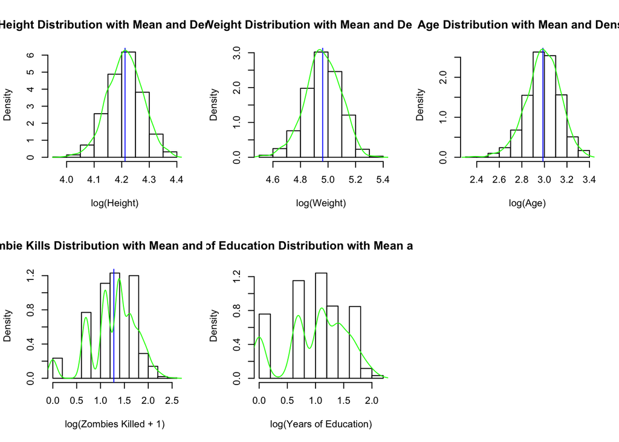

```r
#using histograms to check
par(mfrow = c(2, 3))  # Arrange plots in a 2-row, 3-column grid
#log to reduce skewness
hist(log(zombies$height), freq = FALSE, col = "white", main = "Height Distribution with Mean and Density",
     xlab = "log(Height)", ylab = "Density")
abline(v = mean(log(zombies$height), na.rm = TRUE), col = "blue")
lines(density(log(zombies$height), na.rm = TRUE), col = "green")

hist(log(zombies$weight), freq = FALSE, col = "white", main = "Weight Distribution with Mean and Density",
     xlab = "log(Weight)", ylab = "Density")
abline(v = mean(log(zombies$weight), na.rm = TRUE), col = "blue")
lines(density(log(zombies$weight), na.rm = TRUE), col = "green")

hist(log(zombies$age), freq = FALSE, col = "white", main = "Age Distribution with Mean and Density",
     xlab = "log(Age)", ylab = "Density")
abline(v = mean(log(zombies$age), na.rm = TRUE), col = "blue")
lines(density(log(zombies$age), na.rm = TRUE), col = "green")

hist(log(zombies$zombies_killed + 1), freq = FALSE, col = "white", main = "Zombie Kills Distribution with Mean and Density",
     xlab = "log(Zombies Killed + 1)", ylab = "Density")
abline(v = mean(log(zombies$zombies_killed + 1), na.rm = TRUE), col = "blue")
lines(density(log(zombies$zombies_killed + 1), na.rm = TRUE), col = "green")

hist(log(zombies$years_of_education), freq = FALSE, col = "white", main = "Years of Education Distribution with Mean and Density",
     xlab = "log(Years of Education)", ylab = "Density")
abline(v = mean(log(zombies$years_of_education), na.rm = TRUE), col = "blue")
lines(density(log(zombies$years_of_education), na.rm = TRUE), col = "green")

#Using qqplots to check
par(mfrow = c(2, 3))  # Set up multiple panels for plots
```

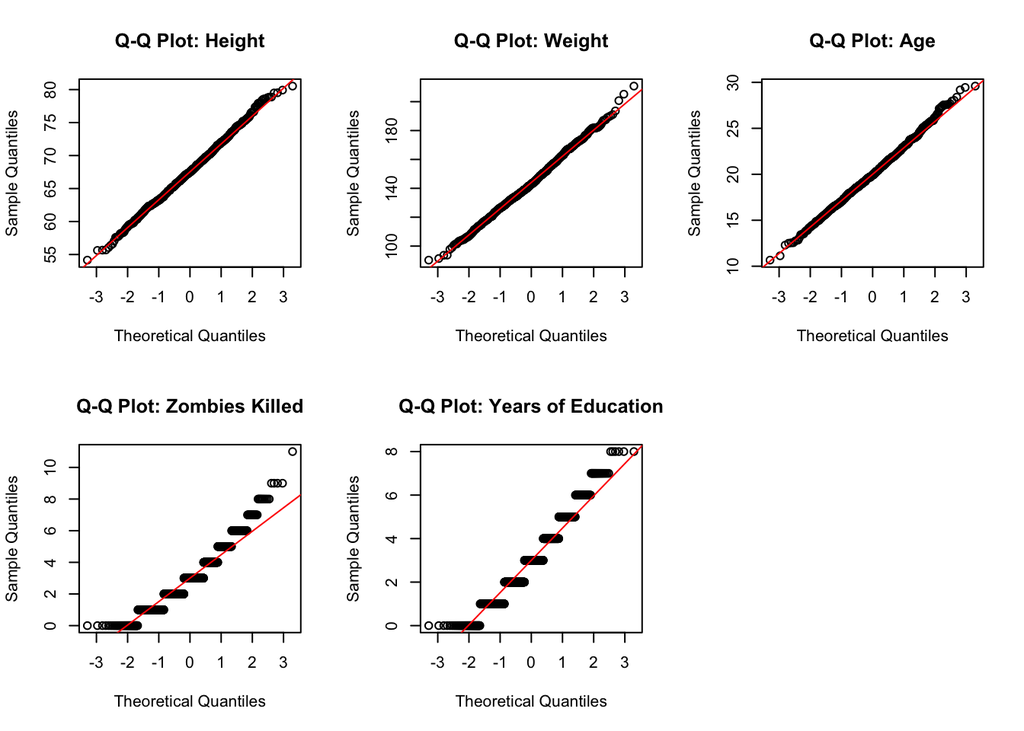

```r
#extracting the heights column from zombies data frame and main is the title.
qqnorm(zombies$height, main = "Q-Q Plot: Height")
qqline(zombies$height, col = "red")

#extract weight
qqnorm(zombies$weight, main = "Q-Q Plot: Weight")
qqline(zombies$weight, col = "red")

#extract age
qqnorm(zombies$age, main = "Q-Q Plot: Age")
qqline(zombies$age, col = "red")

#extract zombies killed
qqnorm(zombies$zombies_killed, main = "Q-Q Plot: Zombies Killed")
qqline(zombies$zombies_killed, col = "red")

#extracts years of education
qqnorm(zombies$years_of_education, main = "Q-Q Plot: Years of Education")
qqline(zombies$years_of_education, col = "red")

par(mfrow = c(1, 1))  # Reset plotting layout for future plots
```

Interpreting the Variables

Height- the histogram shows a symmetric bell shape and the ggplot with the points closely align with the red diagonal line indicates the data is normal.

Weight- the histogram shows a symmetric and bell shape, the ggplot points align closely with the red diagonal, indicated that the data is normal

Years of education- the data is slightly skewed, it may be approximately normal.

## 5.) Now use the sample() function to sample ONE subset of 30 zombie survivors (without replacement) from this population and calculate the mean and sample standard deviation for each variable. Also estimate the standard error for each variable, and construct the 95% confidence interval for each mean. Note that for the variables that are not drawn from the normal distribution, you may need to base your estimate of the CIs on slightly different code than for the normal…

*^^CHANGED TO HEADER 2 SO IT LOOKS MORE ORGANIZED IN THE TABLE OF CONTENT*

*THIS LOOKS SUPER CLEAN AND EASY TO FOLLOW. MY ONLY SUGGESTION IS CAN YOU EXPLAIN IN YOUR COMMENT IS THE LOWER AND UPPER BOUNDS OF THE CI. CAN YOU EXPLAIN FOR EXAMPLE WHY YOU USED 1.96? OVERALL IT LOOKS AWESOME!!!*

```r
set.seed(42) #reproducibility
sample_30 <- zombies[sample(nrow(zombies), 30, replace = FALSE),]  # Take a random sample of 30 zombies without replacement

numeric_vars <- c("height", "weight", "age", "zombies_killed", "years_of_education") #vector to extract from sample

# Compute means for each selected columns
sample_means <- colMeans(sample_30[, numeric_vars])

# Compute sample standard deviations
sample_sds <- apply(sample_30[, numeric_vars], 2, sd)

# Print results
sample_means
```

```
##             height             weight                age     zombies_killed
##          66.230157         138.382811          19.595684           2.766667
## years_of_education
##           2.333333
```

```r
sample_sds
```

```
##             height             weight                age     zombies_killed
##           4.229327          17.924911           3.174797           1.430778
## years_of_education
##           1.604591
```

```r
sample_se <- sample_sds / sqrt(30)  # Standard error formula: SD / sqrt(n)

# Print SE
sample_se
```

```
##             height             weight                age     zombies_killed
##          0.7721660          3.2726259          0.5796360          0.2612232
## years_of_education
##          0.2929569
```

```r
# Compute 95% confidence interval: mean ± 1.96 * SE
ci_lower <- sample_means - 1.96 * sample_se
ci_upper <- sample_means + 1.96 * sample_se

# Combine results into a table
confidence_intervals <- data.frame(Variable = numeric_vars, Mean = sample_means, Lower_95_CI = ci_lower, Upper_95_CI = ci_upper)

# Print the confidence intervals
confidence_intervals
```

```
##                              Variable       Mean Lower_95_CI Upper_95_CI
## height                         height  66.230157   64.716712   67.743603
## weight                         weight 138.382811  131.968464  144.797158
## age                               age  19.595684   18.459598   20.731771
## zombies_killed         zombies_killed   2.766667    2.254669    3.278664
## years_of_education years_of_education   2.333333    1.759138    2.907529
```

## 6.) Now draw 99 more random samples of 30 zombie apocalypse survivors, and calculate the mean for each variable for each of these samples. Together with the first sample you drew, you now have a set of 100 means for each variable (each based on 30 observations), which constitutes a sampling distribution for each variable. What are the means and standard deviations of this distribution of means for each variable? How do the standard deviations of means compare to the standard errors estimated in [5]? What do these sampling distributions look like (a graph might help here)? Are they normally distributed? What about for those variables that you concluded were not originally drawn from a normal distribution?

*^^CHANGED TO HEADER 2 SO IT LOOKS MORE ORGANIZED IN THE TABLE OF CONTENT*

*CODING ALL THE TASKS IN ONE CHUCNK IS A BIT HARD TO FOLLOW SINCE THERES SO MUCH GOING ON FOR THIS PROBLEM. I SUGGEST BREAKING UP THE CODE CHUNCKS TO SAMPING FIRST. THEN FIGURING OUT SD. THEN GRAPHING*

*MAKE SURE TO ALSO ANSWER THE QUESTIONS FROM THE PROBLEM. USING YOUR ORGANIZED AND VISUALLY CLEAR GRAPH: What do these sampling distributions look like (a graph might help here)? Are they normally distributed? What about for those variables that you concluded were not originally drawn from a normal distribution?*

```r
set.seed(42) # Set the random seed for reproducibility

# Defining the numeric variables
numeric_vars <- c("height", "weight", "age", "zombies_killed", "years_of_education")

# Create an empty list to store the sample means
sample_means_list <- list()

# Loop to take 99 random samples of 30 zombie survivors
for (i in 1:99) { sample_i <- zombies[sample(nrow(zombies), 30, replace = FALSE),]  # Sample from zombies dataset without replacement
sample_means_list[[i]] <- colMeans(sample_i[, numeric_vars], na.rm = TRUE)} #holds the means of samples, sample_i is the sample of 30 rows from zombie data set
#colmeans calulates the mean of columns from numeric_vars, ignoring missing values

# Convert the list to a data
sample_means_df <- as.data.frame(matrix(unlist(sample_means_list), nrow = length(sample_means_list), byrow = TRUE)) #unlist- convert to single flat vector, matrix- converts it to matrix form
colnames(sample_means_df) <- numeric_vars  # Assign column names based on numeric_vars

# Add the first sample to the data frame
sample_means_df <- rbind(sample_means_df, sample_means)  # Add the first sample

# Calculate the mean of each variable's sampling distribution
sampling_dist_means <- colMeans(sample_means_df)

# Calculate the standard deviation of each variable's sampling distribution
sampling_dist_sds <- apply(sample_means_df, 2, sd)

# Print the means and standard deviations
sampling_dist_means
```

```
##             height             weight                age     zombies_killed
##          67.661253         143.973458          20.081803           3.023667
## years_of_education
##           2.983000
```

```r
sampling_dist_sds
```

```
##             height             weight                age     zombies_killed
##          0.7853368          3.2249082          0.5769166          0.2887449
## years_of_education
##          0.2920378
```

```r
# Comparison with the estimated standard errors
comparison <- data.frame( Variable = numeric_vars, Estimated_SE = sample_se, Sampling_SD = sampling_dist_sds)

# Print the comparison table
comparison
```

```
##                              Variable Estimated_SE Sampling_SD
## height                         height    0.7721660   0.7853368
## weight                         weight    3.2726259   3.2249082
## age                               age    0.5796360   0.5769166
## zombies_killed         zombies_killed    0.2612232   0.2887449
## years_of_education years_of_education    0.2929569   0.2920378
```

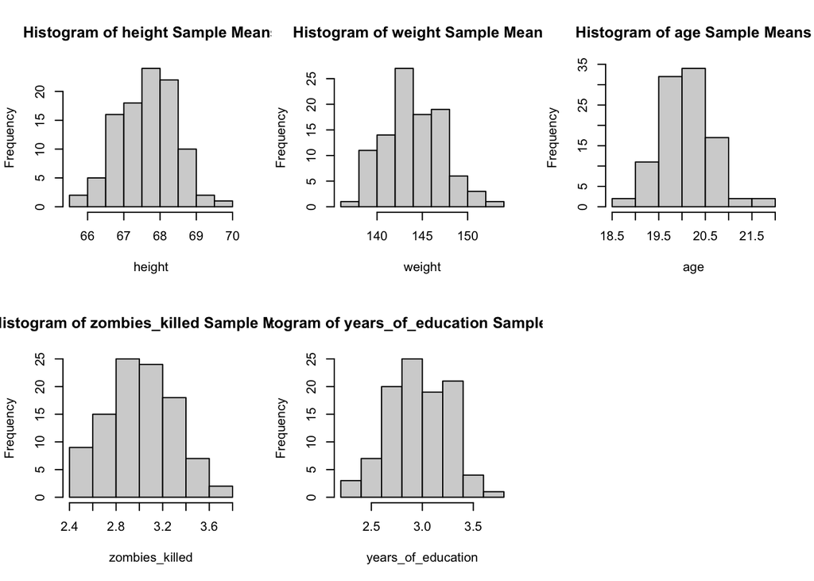

```r
# Create histograms for each variable
par(mfrow = c(2, 3))  # Arrange multiple plots in a 2-row, 3-column grid

for (var in colnames(sample_means_df)) {hist(sample_means_df[[var]], main = paste("Histogram of", var, "Sample Means"), xlab = var)} #loop through each column and create a histogram for each variable

# Create Q-Q plots for each variable
par(mfrow = c(2, 3))  # Arrange multiple plots
```

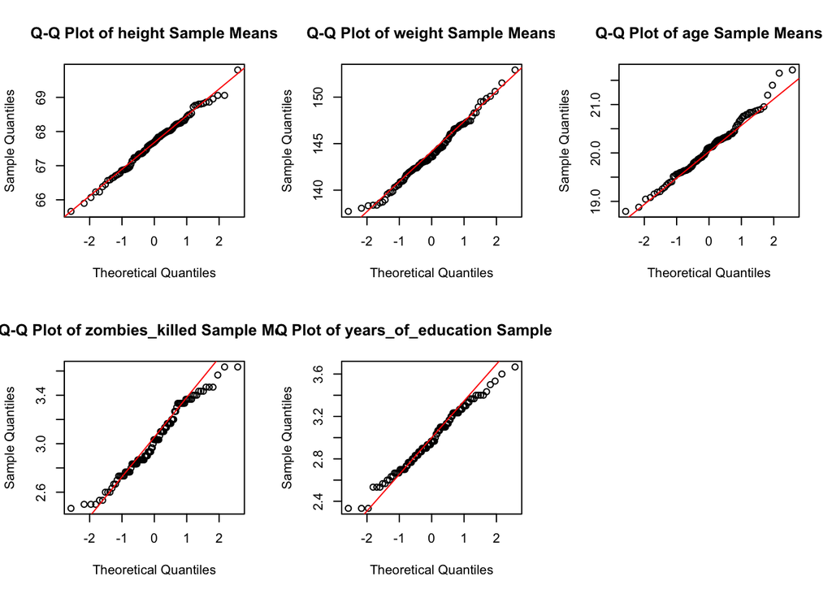

```r
for (var in numeric_vars) { qqnorm(sample_means_df[[var]], main = paste("Q-Q Plot of", var, "Sample Means")) #selects values of the variable from sample_means_df to be plotted.
 qqline(sample_means_df[[var]], col = "red")} #add the reference line to compare
```

Challenges: I’m not sure if I completed 5 and 6 correctly. I’m also not too familiar with loops for question 6 when combining the data. For number 4, there may be an easier way of doing it without listing each plot at a time. (I just referenced one of the modules from class)